# Homework 3: Baseball

Diana Rueda

11/16/2020

## Report Structure

For this assignment, your report will focus on each question separately rather than having a nar- rative of the overall, high-level process. For each question, • include the question • map the (intentionally) casually written question to more precisely identify the relevant vari- ables you need and the rows from the different tables, describing how you are interpreting some of the ambiguous terms • show the SQL and R code you use to get the relevant data • interpret the results, justifying with numerical or graphical summaries. • optionally, show the R code for doing this directly from the data frames not using SQL.

```r
library(DBI)
library(RSQLite)
library(ggplot2)
```

```r
#establish connection to darabase
con <- dbConnect(SQLite(), "~/Documents/lahman2013.sqlite")
tables = dbListTables(con)
tables
```

```
##  [1] "AllstarFull"         "Appearances"         "AwardsManagers"
##  [4] "AwardsPlayers"       "AwardsShareManagers" "AwardsSharePlayers"
##  [7] "Batting"             "BattingPost"         "Fielding"
## [10] "FieldingOF"          "FieldingPost"        "HallOfFame"
## [13] "Managers"            "ManagersHalf"        "Master"
## [16] "Pitching"            "PitchingPost"        "Salaries"
## [19] "Schools"             "SchoolsPlayers"      "SeriesPost"
## [22] "Teams"               "TeamsFranchises"     "TeamsHalf"
## [25] "temp"
```

```r
#get the variable names per table
vars_per_table = sapply(tables, function(t) dbListFields(con, t))
```

### 1. What years does the data cover? are there data for each of these years?

```r
sapply(vars_per_table, function(x) "yearID" %in% x)
```

```
##         AllstarFull         Appearances      AwardsManagers       AwardsPlayers
##                TRUE                TRUE                TRUE                TRUE
## AwardsShareManagers  AwardsSharePlayers             Batting         BattingPost
##                TRUE                TRUE                TRUE                TRUE
##            Fielding          FieldingOF        FieldingPost          HallOfFame
##                TRUE                TRUE                TRUE               FALSE
##            Managers        ManagersHalf              Master            Pitching
##                TRUE                TRUE               FALSE                TRUE
##        PitchingPost            Salaries             Schools      SchoolsPlayers
##                TRUE                TRUE               FALSE               FALSE
##          SeriesPost               Teams     TeamsFranchises           TeamsHalf
##                TRUE                TRUE               FALSE                TRUE
##                temp
##               FALSE
```

My initial intuition was to integrate all the columns across tables working with years to then find the minimum, max and gaps. However, many tables contain a year variable but some do not make sense as a response to this question. For example, year of a player’s birth does not relate closely to useful baseball statistics. It would be more useful information if we interpret the question as asking for the years of game or team related data recolation. I will use the Teams table since it contains yearly team statistics with a variable yearID. Then I will find the min and max of the unique values for this variable.

As for the second part of this question I decided to compare the first few rows of the data grouped by year using the Teams table to the last few rows. Since some of the data goes very far back in time I assume some of it would be missing in the beginning. Then as the sport or record keeping evolved more information became available with each year.

```r
# get the minimum year and maximum year value from Teams table
min_year = dbGetQuery(con, "SELECT min(yearID) FROM Teams")
max_year = dbGetQuery(con, "SELECT max(yearID) FROM Teams")
```

```r
#print the head of years that appear in the Teams table to check for initial gaps
years = dbGetQuery(con, "SELECT DISTINCT yearID FROM Teams")
head(years)
```

```
##   yearID
## 1   1871
## 2   1872
## 3   1873
## 4   1874
## 5   1875
## 6   1876
```

```r
#show head of table after grouped by year
years_NA = dbGetQuery(con, "SELECT * FROM Teams GROUP BY yearID")
head(years_NA)
```

```
##   yearID lgID teamID franchID divID Rank  G Ghome  W  L DivWin WCWin LgWin
## 1   1871   NA    BS1      BNA  <NA>    3 31    NA 20 10   <NA>  <NA>     N
## 2   1872   NA    BL1      BLC  <NA>    2 58    NA 35 19   <NA>  <NA>     N
## 3   1873   NA    BL1      BLC  <NA>    3 57    NA 34 22   <NA>  <NA>     N
## 4   1874   NA    BL1      BLC  <NA>    8 47    NA  9 38   <NA>  <NA>     N
## 5   1875   NA    BR2      BRA  <NA>   11 44    NA  2 42   <NA>  <NA>     N
## 6   1876   NL    BSN      ATL  <NA>    4 70    NA 39 31   <NA>  <NA>     N
##   WSWin   R   AB   H  2B 3B HR BB SO SB CS HBP SF  RA  ER  ERA CG SHO SV IPouts
## 1  <NA> 401 1372 426  70 37  3 60 19 73 NA  NA NA 303 109 3.55 22   1  3    828
## 2  <NA> 617 2576 747  94 35 14 27 28 35 15  NA NA 434 173 3.02 48   1  1   1545
## 3  <NA> 644 2563 810 119 39 12 40 25 21 10  NA NA 451 170 3.01 55   1  0   1524
## 4  <NA> 227 1781 435  53  8  1 24  0 NA NA  NA NA 505 201 4.31 43   0  0   1260
## 5  <NA> 132 1547 304  32  9  2 10  0 NA NA  NA NA 438 174 3.95 31   0  0   1188
## 6  <NA> 471 2722 723  96 24  9 58 98 NA NA  NA NA 450 176 2.51 49   3  7   1896
##    HA HRA BBA SOA   E DP   FP                 name                park
## 1 367   2  42  23 225 NA 0.83 Boston Red Stockings South End Grounds I
## 2 566   3  63   0 432 NA 0.82   Baltimore Canaries      Newington Park
## 3 680   4  42  34 366 NA 0.85   Baltimore Canaries      Newington Park
## 4 643   4  37   0 355 NA 0.81   Baltimore Canaries      Newington Park
## 5 531   9  22   0 426 NA 0.80   Brooklyn Atlantics       Union Grounds
## 6 732   7 104  77 422 42 0.86      Boston Red Caps South End Grounds I
##   attendance BPF PPF teamIDBR teamIDlahman45 teamIDretro
## 1         NA 103  98      BOS            BS1         BS1
## 2         NA 106 102      BAL            BL1         BL1
## 3         NA 101 102      BAL            BL1         BL1
## 4         NA 102 104      BAL            BL1         BL1
## 5         NA  88  94      BRA            BR2         BR2
## 6         NA 102  98      BSN            BSN         BSN
```

```r
#show the last rows of years table to compare with the head
tail(years_NA)
```

```
##     yearID lgID teamID franchID divID Rank   G Ghome  W  L DivWin WCWin LgWin
## 138   2008   AL    BAL      BAL     E    5 161    81 68 93      N     N     N
## 139   2009   AL    BAL      BAL     E    5 162    81 64 98      N     N     N
## 140   2010   AL    BAL      BAL     E    5 162    81 66 96      N     N     N
## 141   2011   AL    BAL      BAL     E    5 162    81 69 93      N     N     N
## 142   2012   AL    BAL      BAL     E    2 162    81 93 69      N     Y     N
## 143   2013   AL    BAL      BAL     E    3 162    81 85 77      N     N     N
##     WSWin   R   AB    H  2B 3B  HR  BB   SO SB CS HBP SF  RA  ER  ERA CG SHO SV
## 138     N 782 5559 1486 322 30 172 533  990 81 37  42 48 869 810 5.15  4   4 35
## 139     N 741 5618 1508 307 19 160 517 1013 76 37  39 46 876 817 5.16  2   3 31
## 140     N 613 5554 1440 264 21 133 424 1056 76 34  54 45 785 733 4.59  3   7 35
## 141     N 708 5585 1434 273 13 191 452 1120 81 25  52 43 860 786 4.92  3   7 32
## 142     N 712 5560 1375 270 16 214 480 1315 58 29  50 30 705 642 3.90  1   1 55
## 143     N 745 5620 1460 298 14 212 416 1125 79 29  36 45 709 678 4.20  2   1 57
##     IPouts   HA HRA BBA  SOA   E  DP    FP              name
```

[output cut: 20 more lines]

The data covers from 1871 to 2013 of relevant baseball data without gaps. The intuition about the kind of missing data was correct. If we look at the Teams table by years, certain columns contain missing values for the first few rows/years and eventualy provide information about that feature. This could be due to a feature that was introduced to the sport later on. Some of the features that reflect this in the table Teams are diviD, Ghome, DivWin, WCWin, WSWin, HBP, SF and DP. More analysis could be made to determine the beginning of each.

### 2. How many (unique) people are included in the database? How many are players, managers, etc?

From looking at the tables’ variables we can see that all people in the data are identified by a unique playerID value. This uncludes both managers and players. The Master table is suposed to contain the playerIDs for all the people in the data. To check that we have indeed all people we should go over each table that contains a playerID column to obtain other unique values that did not appear in the Master table. These could be typos or new players or managers. If any we should add them to the list of unique playerIDs from the master.

Then, in order to adress the second part of the question we should count the number of unique playerIDs in the table Managers. Since some people are both players and managers we should also count how many are both. To count how many are both we should count how many observations are ‘Y’ in the variable plyrMgr of Managers table.

```r
#list of unique playerID in Master table
people = dbGetQuery(con, "SELECT DISTINCT playerID FROM Master")
head(people)
```

```
##    playerID
## 1 aardsda01
## 2 aaronha01
## 3 aaronto01
## 4  aasedo01
## 5  abadan01
## 6  abadfe01
```

```r
#get list of table names with playerID column
has_playerID = which(sapply(vars_per_table, function(x) "playerID" %in% x)==TRUE)

#across table get complete rows of all intances of the playersID that are not in the Master table. Typos?
others = lapply(tables[has_playerID], function(x) dbGetQuery(con, sprintf("SELECT * FROM %s WHERE NOT playerID IN (SELECT DISTINCT playerID FROM Master)", x)))

#get unique playerID across tables of the ones not in Master. Typos?
ids = unique(unlist(sapply(others, `[[`, "playerID")))
ids
```

```
## [1] "keanejo99" "Cabremi01" "nomohid01" "cammebi99" "hengled99"
```

```r
#nohohid01 is in HallofFame
#Cabremi01 is in Awards players
#keanejo99 is in awards managers
#keanejo99, cammebi99 and hengled99 are in managers
```

```r
#se string distances with adist to find similar instances of the playerIDs not in Master saved in ids
master = dbGetQuery(con, "SELECT * FROM Master")
m = adist(ids, master$playerID)

#find closest matches and put side to side to check for typos
cbind(ids, master$playerID[apply(m, 1, which.min)])
```

```
##      ids
## [1,] "keanejo99" "kenejo99"
## [2,] "Cabremi01" "cabremi01"
## [3,] "nomohid01" "nomohi01"
## [4,] "cammebi99" "mackebi99"
## [5,] "hengled99" "hengled01"
```

```r
#the total number of people in the data are the length of the unique values of playerID in Master plus the number of unique playerID found outside of Master that are not typos
num_unique_people = dim(people)[1] + 5
num_unique_people
```

```
## [1] 18359
```

```r
total_people = dim(people)[1] + 2 #because 3 are typos
total_people
```

```
## [1] 18356
```

```r
#find number of managers
#find people that typos might overcount
repeat_people = master$playerID[apply(m, 1, which.min)][1:3]

managers = dbGetQuery(con, "SELECT * FROM Managers")
dim(managers)
```

```
## [1] 3337   10
```

```r
dist_managers = dbGetQuery(con, "SELECT DISTINCT playerID FROM Managers")
dim(dist_managers)
```

```
## [1] 682   1
```

```r
#check for the repeat playerID
bool_repeat = unlist(ids) %in% unlist(dist_managers)
bool_repeat
```

```
## [1] FALSE FALSE FALSE  TRUE  TRUE
```

```r
bool_repeat = unlist(repeat_people) %in% unlist(dist_managers)
bool_repeat
```

```
## [1]  TRUE FALSE FALSE
```

According to these results, Managers is not double counting due to typos because it does not contain both versions of the word containing a typo. Thus, for the sake of counting we can procede as is.

```r
total_managers = dim(dist_managers)[1]
total_managers
```

```
## [1] 682
```

```r
#get the unique playerIDs that have Y for plyrMgr
plyrMgr = dbGetQuery(con, "SELECT DISTINCT playerID FROM Managers WHERE plyrMgr = 'Y'")
num_plyrMgr = dim(plyrMgr)[1]
num_plyrMgr
```

```
## [1] 247
```

```r
num_all_players = total_people - total_managers + num_plyrMgr
num_all_players
```

```
## [1] 17921
```

```r
num_only_players = total_people - total_managers
num_only_players
```

```
## [1] 17674
```

```r
num_mgr_not_players = total_managers - num_plyrMgr
num_mgr_not_players
```

```
## [1] 435
```

The dataset contains 18359 unique playerIDs of which 3 are IDs with typos, so the total number of people in the data is 18356.  
The total number of players including players who are managers is 17921. The total number of players who are not managers is 17674.  
The total number of managers is 682. The total number of managers who are not players is 435.

### 3. How many players became managers?

The Managers table contains a variable plyrMgr which is Y if a manager is a player and N if the manager is not a player. Thus we need to count the number of unique values of playerID that have Y for column plyrMgr.

```r
#might have to do something with yearID
#get the unique playerIDs that have Y for plyrMgr
plyrMgr = dbGetQuery(con, "SELECT DISTINCT playerID FROM Managers WHERE plyrMgr = 'Y'")
num_plyrMgr = dim(plyrMgr)[1]
num_plyrMgr
```

```
## [1] 247
```

Agreeing with the computation from the question before, the number of players who became managers is 247.

### 4. How many players are there in each year, from 2000 to 2013? Do all teams have the same number of players?

To determine the number of players in each year we can use the table Salaries since it shows the salary of players by year. We can assume a player “is” in a year if it is getting paid that year. By selecting those observations between 2000 and 2013, grouping by year and counting the number of unique players in each year we can determine the number by year.

To find if all teams have the same number of players we should obtain first the number of players each team has which is open to interpretation. It can be the number of players per team as of the most current year, the number of players per team per year (2000 - 2013) or the number of players that have played for that team from 2000 to 2013.

For a meaningful path of analysis the number of players per team per year might be the best interpretation since we can then look at how teams have grown.

This task can be accomplished by pulling information from the Salaries table as well (it contains yearID, playerID, teamID). We use SQL query to obtain one table from each year that contains the number of member per team. Then we merge these tables by teamID to analyse the results

```r
#obtain number of players per year
players_per_year = dbGetQuery(con, "SELECT yearID, COUNT(*) as num_players FROM Salaries WHERE yearID BETWEEN 2000 AND 2013 GROUP BY yearID")
players_per_year
```

```
##    yearID num_players
## 1    2000         836
## 2    2001         860
## 3    2002         846
## 4    2003         827
## 5    2004         831
## 6    2005         831
## 7    2006         819
## 8    2007         842
## 9    2008         856
## 10   2009         813
## 11   2010         830
## 12   2011         839
## 13   2012         848
## 14   2013         815
```

```r
num_plyrs_grouped = sum(players_per_year$num_players)

num_plyrs_db = unlist(dbGetQuery(con, "SELECT COUNT(*) as num_players FROM Salaries WHERE yearID BETWEEN 2000 AND 2013"))

is_correct = num_plyrs_db == num_plyrs_grouped
is_correct
```

```
## num_players
##        TRUE
```

```r
#get number of players by team in 2000
plyr_per_team_2000 = dbGetQuery(con, "SELECT teamID, COUNT(*) as num_players FROM Salaries WHERE yearID = 2000 GROUP BY teamID")

#get number of players by team in 2001
plyr_per_team_2001 = dbGetQuery(con, "SELECT teamID, COUNT(*) as num_players FROM Salaries WHERE yearID = 2001 GROUP BY teamID")

#get number of players by team in 2002
plyr_per_team_2002 = dbGetQuery(con, "SELECT teamID, COUNT(*) as num_players FROM Salaries WHERE yearID = 2002 GROUP BY teamID")

#get number of players by team in 2003
plyr_per_team_2003 = dbGetQuery(con, "SELECT teamID, COUNT(*) as num_players FROM Salaries WHERE yearID = 2003 GROUP BY teamID")

#get number of players by team in 2004
plyr_per_team_2004 = dbGetQuery(con, "SELECT teamID, COUNT(*) as num_players FROM Salaries WHERE yearID = 2004 GROUP BY teamID")

#get number of players by team in 2005
plyr_per_team_2005 = dbGetQuery(con, "SELECT teamID, COUNT(*) as num_players FROM Salaries WHERE yearID = 2005 GROUP BY teamID")

#get number of players by team in 2006
plyr_per_team_2006 = dbGetQuery(con, "SELECT teamID, COUNT(*) as num_players FROM Salaries WHERE yearID = 2006 GROUP BY teamID")

#get number of players by team in 2007
plyr_per_team_2007 = dbGetQuery(con, "SELECT teamID, COUNT(*) as num_players FROM Salaries WHERE yearID = 2007 GROUP BY teamID")

#get number of players by team in 2008
plyr_per_team_2008 = dbGetQuery(con, "SELECT teamID, COUNT(*) as num_players FROM Salaries WHERE yearID = 2008 GROUP BY teamID")

#get number of players by team in 2009
plyr_per_team_2009 = dbGetQuery(con, "SELECT teamID, COUNT(*) as num_players FROM Salaries WHERE yearID = 2009 GROUP BY teamID")

#get number of players by team in 2010
plyr_per_team_2010 = dbGetQuery(con, "SELECT teamID, COUNT(*) as num_players FROM Salaries WHERE yearID = 2010 GROUP BY teamID")

#get number of players by team in 2011
plyr_per_team_2011 = dbGetQuery(con, "SELECT teamID, COUNT(*) as num_players FROM Salaries WHERE yearID = 2011 GROUP BY teamID")

#get number of players by team in 2012
plyr_per_team_2012 = dbGetQuery(con, "SELECT teamID, COUNT(*) as num_players FROM Salaries WHERE yearID = 2012 GROUP BY teamID")

#get number of players by team in 2013
plyr_per_team_2013 = dbGetQuery(con, "SELECT teamID, COUNT(*) as num_players FROM Salaries WHERE yearID = 2013 GROUP BY teamID")
```

```r
#get name of teams in Salaries
teamID = dbGetQuery(con, "SELECT DISTINCT teamID FROM Salaries")

#create dataframe
plyrs_per_team = Reduce(function(x,y) merge(x=x, y=y, by = "teamID", all.x = TRUE), list(teamID, plyr_per_team_2000[, c("teamID", "num_players")], plyr_per_team_2001[, c("teamID", "num_players")], plyr_per_team_2002[, c("teamID", "num_players")], plyr_per_team_2003[, c("teamID", "num_players")], plyr_per_team_2004[, c("teamID", "num_players")], plyr_per_team_2005[, c("teamID", "num_players")], plyr_per_team_2006[, c("teamID", "num_players")], plyr_per_team_2007[, c("teamID", "num_players")], plyr_per_team_2008[, c("teamID", "num_players")], plyr_per_team_2009[, c("teamID", "num_players")], plyr_per_team_2010[, c("teamID", "num_players")], plyr_per_team_2011[, c("teamID", "num_players")], plyr_per_team_2012[, c("teamID", "num_players")], plyr_per_team_2013[, c("teamID", "num_players")]))
colnames(plyrs_per_team) = c("teamID", 2000:2013)
plyrs_per_team[is.na(plyrs_per_team)] = 0
head(plyrs_per_team)
```

```
##   teamID 2000 2001 2002 2003 2004 2005 2006 2007 2008 2009 2010 2011 2012 2013
## 1    ANA   30   30   28   27   27    0    0    0    0    0    0    0    0    0
## 2    ARI   28   28   33   25   29   27   26   28   28   26   26   27   27   30
## 3    ATL   30   31   28   27   28   25   29   28   30   29   27   26   29   27
## 4    BAL   29   29   32   29   28   28   28   27   32   26   26   26   28   26
## 5    BOS   30   32   30   27   30   28   27   28   28   29   29   27   34   29
## 6    CAL    0    0    0    0    0    0    0    0    0    0    0    0    0    0
```

Teams have different number of players across the years but the tend to be around 30.

### 5. What team won the World Series in 2010? Include the name of the team, the league and division.

The table Teams contains yearID, name which contains the team’s full name, lgID which contains the league, divID which has the team’s division and WSWin which records if the team won the world series. In order to obtain the information needed, we select the name, lgID and divID columns, and pull the observation where yearID equals 10 and WSWin equals Y.

```r
won_WS_2010 = dbGetQuery(con, "SELECT name, lgID, divID FROM Teams WHERE yearID = 2010 AND WSWin = 'Y'")
won_WS_2010
```

```
##                   name lgID divID
## 1 San Francisco Giants   NL     W
```

The team that won the World Series in 2010 is the San Francisco Giants.

### 6. What team lost the World Series each year? Again, include the name of the team, league and division.

This column WSWin in table Teams provides only who won and not who went and lost. Thus, we should find another way to determine the loser. Since the participants of the World Series are the champions of American League (AL in lgID) and National League (NA in lgID) according to Wikipedia, we can find the two champions of these two leages each year and select the one who did not win the World Series.

Useful columns are yearID, name which contains the team’s full name, lgID which contains the league, divID which has the team’s division, LgWin which tells if the team won the league and WSWin which records if the team won the world series.

```r
WS_loser_by_year = dbGetQuery(con, "SELECT name, lgID, divID, yearID, LgWin, WSWin FROM Teams WHERE (WSWin = 'N' AND LgWin = 'Y' AND lgID = 'AL') OR (WSWin = 'N' AND LgWin = 'Y' AND lgID = 'NL') GROUP BY yearID")
head(WS_loser_by_year)
```

```
##                      name lgID divID yearID LgWin WSWin
## 1 Chicago White Stockings   NL  <NA>   1885     Y     N
## 2 Chicago White Stockings   NL  <NA>   1886     Y     N
## 3    Brooklyn Bridegrooms   NL  <NA>   1890     Y     N
## 4      Pittsburgh Pirates   NL  <NA>   1903     Y     N
## 5  Philadelphia Athletics   AL  <NA>   1905     Y     N
## 6            Chicago Cubs   NL  <NA>   1906     Y     N
```

As we can se the table tells the teams won the league but lost to the champion of the World Series. The column divID contains NA calues at the beginning which might be due to the simplicity of the sport in those years. Perhaps divisions did not exist back then.

### 7. Compute the table of World Series winners for all years, again with the name of the team, league and division.

In order to obtain this information we follow the same logic as in question 5, but this time we generalize it and group it by years.

The table Teams contains yearID, name which contains the team’s full name, lgID which contains the league, divID which has the team’s division and WSWin which records if the team won the world series. We should select the name, lgID and divID columns, pull the observation where WSWin equals Y and group by yearID since we cant the champion of each year.

```r
WS_champ_by_year = dbGetQuery(con, "SELECT name, lgID, divID, yearID, WSWin FROM Teams WHERE WSWin = 'Y' GROUP BY yearID")

head(WS_champ_by_year)
```

```
##                 name lgID divID yearID WSWin
## 1   Providence Grays   NL  <NA>   1884     Y
## 2   St. Louis Browns   AA  <NA>   1886     Y
## 3 Detroit Wolverines   NL  <NA>   1887     Y
## 4    New York Giants   NL  <NA>   1888     Y
## 5    New York Giants   NL  <NA>   1889     Y
## 6   Boston Americans   AL  <NA>   1903     Y
```

### 10. In 2003, what were the three highest salaries? (We refer here to unique salaries, i.e., there may be several players getting the exact same amount.) Find the players who got any of these 3 salaries with all of their details?

The first thing we need to do is figure out what the three highest salaries are. Then we find who earned those salaries.

The table Salaries can help us find this answers. To get the highest three salaries we use the column salary from this table and order it by salary in decending order. We limit the results to 3 and use DISTINCT in the select statement to obtain only the three unique values that are the highest of all.

```r
dbGetQuery(con, "SELECT DISTINCT salary FROM Salaries ORDER BY -salary LIMIT 3")
```

```
##    salary
## 1 3.3e+07
## 2 3.2e+07
## 3 3.0e+07
```

Once we have found these we can use them in combination with tables Master and Salaries to see who earned those salaries. The table Master will provide useful information on the demografict of the players as long as we choose the correct columns. On the other hand we will use the table Salaries only for the column salary. In one query we can obtain some of the data needed for all players with the help of joining tables matching by column playerID and indicating the specific values of salaries.

```r
demo = dbGetQuery(con, "SELECT salary, yearID, M.playerID, nameFirst, nameLast, nameGiven, teamID, lgID, birthYear, birthCountry, deathYear, weight, height, bats, throws FROM Master AS M, Salaries AS S ON M.playerID = S.playerID WHERE salary = 33000000 OR salary = 32000000 or salary = 30000000")
demo
```

```
##    salary yearID  playerID nameFirst  nameLast          nameGiven teamID lgID
## 1 3.3e+07   2009 rodrial01      Alex Rodriguez Alexander Emmanuel    NYA   AL
## 2 3.3e+07   2010 rodrial01      Alex Rodriguez Alexander Emmanuel    NYA   AL
## 3 3.2e+07   2011 rodrial01      Alex Rodriguez Alexander Emmanuel    NYA   AL
## 4 3.0e+07   2012 rodrial01      Alex Rodriguez Alexander Emmanuel    NYA   AL
##   birthYear birthCountry deathYear weight height bats throws
## 1      1975          USA        NA    225     75    R      R
## 2      1975          USA        NA    225     75    R      R
## 3      1975          USA        NA    225     75    R      R
## 4      1975          USA        NA    225     75    R      R
```

We have obtained some data but there are other tables containing some interesting variables about our players which could be interesting. For instance the tables Managers, Fielding, Pitching and Batting. From them we can gather the number of games that the player was pitcher ot at bat.

```r
#alex_mgr
if(dim(dbGetQuery(con, "SELECT yearID, plyrMgr FROM Managers WHERE playerID = 'rodrial01' AND yearID BETWEEN 2009 AND 2012"))[1] == 0) {
  alex_mgr = data.frame('yearID' = 2009:2012, 'manager' = c('N','N','N','N'))
}else{
  alex_mgr = dbGetQuery(con, "SELECT yearID, plyrMgr FROM Managers WHERE playerID = 'rodrial01' AND yearID BETWEEN 2009 AND 2012")
}

#alex_games_fielding
if(dim(dbGetQuery(con, "SELECT yearID, G FROM Fielding WHERE playerID = 'rodrial01' AND yearID BETWEEN 2009 AND 2012")
)[1] == 0) {
  alex_games_fielding = data.frame('yearID' = 2009:2012, 'games_fielding' = c(0,0,0,0))
}else{
  alex_games_fielding = dbGetQuery(con, "SELECT yearID, SUM(G) AS games_fielding FROM Fielding WHERE playerID = 'rodrial01' AND yearID BETWEEN 2009 AND 2012 GROUP BY yearID")
}

#alex_games_pitching
if(dim(dbGetQuery(con, "SELECT yearID, G FROM Pitching WHERE playerID = 'rodrial01' AND yearID BETWEEN 2009 AND 2012")
)[1] == 0) {
  alex_games_pitching = data.frame('yearID' = 2009:2012, 'games_pitching' = c(0,0,0,0))
}else{
  alex_games_pitching = dbGetQuery(con, "SELECT yearID, G AS games_pitching FROM Pitching WHERE playerID = 'rodrial01' AND yearID BETWEEN 2009 AND 2012")
}

#alex_games_batting
if(dim(dbGetQuery(con, "SELECT yearID, G FROM Batting WHERE playerID = 'rodrial01' AND yearID BETWEEN 2009 AND 2012")
)[1] == 0) {
  alex_games_batting = data.frame('yearID' = 2009:2012, 'games_batting' = c(0,0,0,0))
}else{
  alex_games_batting = dbGetQuery(con, "SELECT yearID, G AS games_batting FROM Batting WHERE playerID = 'rodrial01' AND yearID BETWEEN 2009 AND 2012")
}

#alex_awards
award = dbGetQuery(con, "SELECT yearID, awardID FROM AwardsPlayers WHERE playerID = 'rodrial01' AND yearID BETWEEN 2009 AND 2012")

alex_awards = data.frame('yearID' = 2009:2012, 'award' = c(award[1,2],0,0,0))
```

```r
#create a data frame with all the results
yearID = data.frame('yearID' = 2009:2012)
alex_details = Reduce(function(x,y) merge(x=x, y=y, by = "yearID", all.x = TRUE), list(yearID, demo, alex_awards, alex_mgr, alex_games_batting, alex_games_fielding, alex_games_pitching))
alex_details
```

```
##   yearID  salary  playerID nameFirst  nameLast          nameGiven teamID lgID
## 1   2009 3.3e+07 rodrial01      Alex Rodriguez Alexander Emmanuel    NYA   AL
## 2   2010 3.3e+07 rodrial01      Alex Rodriguez Alexander Emmanuel    NYA   AL
## 3   2011 3.2e+07 rodrial01      Alex Rodriguez Alexander Emmanuel    NYA   AL
## 4   2012 3.0e+07 rodrial01      Alex Rodriguez Alexander Emmanuel    NYA   AL
##   birthYear birthCountry deathYear weight height bats throws           award
## 1      1975          USA        NA    225     75    R      R Babe Ruth Award
## 2      1975          USA        NA    225     75    R      R               0
## 3      1975          USA        NA    225     75    R      R               0
## 4      1975          USA        NA    225     75    R      R               0
##   manager games_batting games_fielding games_pitching
## 1       N           124            125              0
## 2       N           137            136              0
## 3       N            99             89              0
## 4       N           122             81              0
```

To prove that the salaries selected were correct we can see beyond the first three

```r
dbGetQuery(con, "SELECT salary, yearID FROM Salaries ORDER BY -salary LIMIT 6")
```

```
##    salary yearID
## 1 3.3e+07   2009
## 2 3.3e+07   2010
## 3 3.2e+07   2011
## 4 3.0e+07   2012
## 5 2.9e+07   2013
## 6 2.8e+07   2008
```

### 11. For 2010, compute the total payroll of each of the different teams. Next compute the team payrolls for all years in the database for which we have salary information. Display these in a plot.

The first part of the question can be answered with the sum of salary variable in Salaries table when grouping by teamID. This way we obtain the salaries a team has from the its creation or the beginning of the data to 2013 or its desimation.

The table Salary will be enough to compute the total payroll across years per team. We can accomplish this by collecting the sum of salary per year by team with the use of SUM on salary and ORDER BY on yearID. We then merge these data frames by teamID to hace all the information together.

```r
#salaries of teams in total by team
salaries_all = dbGetQuery(con, "SELECT teamID, SUM(salary) FROM Salaries GROUP BY teamID")
head(salaries_all)
```

```
##   teamID SUM(salary)
## 1    ANA   468091973
## 2    ARI  1112113728
## 3    ATL  1785337784
## 4    BAL  1526784038
## 5    BOS  2293681006
## 6    CAL   271978930
```

```r
#salaries of teams by years
ANA_per_year = dbGetQuery(con, "SELECT yearID, SUM(salary) FROM Salaries WHERE teamID = 'ANA' GROUP BY yearID")

ARI_per_year = dbGetQuery(con, "SELECT yearID, SUM(salary) FROM Salaries WHERE teamID = 'ARI' GROUP BY yearID")

ATL_per_year = dbGetQuery(con, "SELECT yearID, SUM(salary) FROM Salaries WHERE teamID = 'ATL' GROUP BY yearID")

BAL_per_year = dbGetQuery(con, "SELECT yearID, SUM(salary) FROM Salaries WHERE teamID = 'BAL' GROUP BY yearID")

BOS_per_year = dbGetQuery(con, "SELECT yearID, SUM(salary) FROM Salaries WHERE teamID = 'BOS' GROUP BY yearID")

CAL_per_year = dbGetQuery(con, "SELECT yearID, SUM(salary) FROM Salaries WHERE teamID = 'CAL' GROUP BY yearID")

CHA_per_year = dbGetQuery(con, "SELECT yearID, SUM(salary) FROM Salaries WHERE teamID = 'CHA' GROUP BY yearID")

CHN_per_year = dbGetQuery(con, "SELECT yearID, SUM(salary) FROM Salaries WHERE teamID = 'CHN' GROUP BY yearID")

CIN_per_year = dbGetQuery(con, "SELECT yearID, SUM(salary) FROM Salaries WHERE teamID = 'CIN' GROUP BY yearID")

CLE_per_year = dbGetQuery(con, "SELECT yearID, SUM(salary) FROM Salaries WHERE teamID = 'CLE' GROUP BY yearID")

COL_per_year = dbGetQuery(con, "SELECT yearID, SUM(salary) FROM Salaries WHERE teamID = 'COL' GROUP BY yearID")

DET_per_year = dbGetQuery(con, "SELECT yearID, SUM(salary) FROM Salaries WHERE teamID = 'DET' GROUP BY yearID")

FLO_per_year = dbGetQuery(con, "SELECT yearID, SUM(salary) FROM Salaries WHERE teamID = 'FLO' GROUP BY yearID")

HOU_per_year = dbGetQuery(con, "SELECT yearID, SUM(salary) FROM Salaries WHERE teamID = 'HOU' GROUP BY yearID")

KCA_per_year = dbGetQuery(con, "SELECT yearID, SUM(salary) FROM Salaries WHERE teamID = 'KCA' GROUP BY yearID")

LAA_per_year = dbGetQuery(con, "SELECT yearID, SUM(salary) FROM Salaries WHERE teamID = 'LAA' GROUP BY yearID")

LAN_per_year = dbGetQuery(con, "SELECT yearID, SUM(salary) FROM Salaries WHERE teamID = 'LAN' GROUP BY yearID")

MIA_per_year = dbGetQuery(con, "SELECT yearID, SUM(salary) FROM Salaries WHERE teamID = 'MIA' GROUP BY yearID")

MIL_per_year = dbGetQuery(con, "SELECT yearID, SUM(salary) FROM Salaries WHERE teamID = 'MIL' GROUP BY yearID")

MIN_per_year = dbGetQuery(con, "SELECT yearID, SUM(salary) FROM Salaries WHERE teamID = 'MIN' GROUP BY yearID")

ML4_per_year = dbGetQuery(con, "SELECT yearID, SUM(salary) FROM Salaries WHERE teamID = 'ML4' GROUP BY yearID")

MON_per_year = dbGetQuery(con, "SELECT yearID, SUM(salary) FROM Salaries WHERE teamID = 'MON' GROUP BY yearID")

NYA_per_year = dbGetQuery(con, "SELECT yearID, SUM(salary) FROM Salaries WHERE teamID = 'NYA' GROUP BY yearID")

NYN_per_year = dbGetQuery(con, "SELECT yearID, SUM(salary) FROM Salaries WHERE teamID = 'NYN' GROUP BY yearID")

OAK_per_year = dbGetQuery(con, "SELECT yearID, SUM(salary) FROM Salaries WHERE teamID = 'OAK' GROUP BY yearID")

PHI_per_year = dbGetQuery(con, "SELECT yearID, SUM(salary) FROM Salaries WHERE teamID = 'PHI' GROUP BY yearID")

PIT_per_year = dbGetQuery(con, "SELECT yearID, SUM(salary) FROM Salaries WHERE teamID = 'PIT' GROUP BY yearID")

SDN_per_year = dbGetQuery(con, "SELECT yearID, SUM(salary) FROM Salaries WHERE teamID = 'SDN' GROUP BY yearID")

SEA_per_year = dbGetQuery(con, "SELECT yearID, SUM(salary) FROM Salaries WHERE teamID = 'SEA' GROUP BY yearID")

SFN_per_year = dbGetQuery(con, "SELECT yearID, SUM(salary) FROM Salaries WHERE teamID = 'SFN' GROUP BY yearID")

SLN_per_year = dbGetQuery(con, "SELECT yearID, SUM(salary) FROM Salaries WHERE teamID = 'SLN' GROUP BY yearID")

TBA_per_year = dbGetQuery(con, "SELECT yearID, SUM(salary) FROM Salaries WHERE teamID = 'TBA' GROUP BY yearID")

TEX_per_year = dbGetQuery(con, "SELECT yearID, SUM(salary) FROM Salaries WHERE teamID = 'TEX' GROUP BY yearID")

TOR_per_year = dbGetQuery(con, "SELECT yearID, SUM(salary) FROM Salaries WHERE teamID = 'TOR' GROUP BY yearID")

WAS_per_year = dbGetQuery(con, "SELECT yearID, SUM(salary) FROM Salaries WHERE teamID = 'WAS' GROUP BY yearID")
```

```r
#get year IDs in Salaries
yearID = dbGetQuery(con, "SELECT DISTINCT yearID FROM Salaries")

#create dataframe
salaries_per_teams = Reduce(function(x,y) merge(x=x, y=y, by = "yearID", all.x = TRUE), list(yearID, ATL_per_year,  BAL_per_year, BOS_per_year, CAL_per_year, CHA_per_year, CHN_per_year, CIN_per_year, CLE_per_year, DET_per_year, HOU_per_year, KCA_per_year, LAN_per_year, MIN_per_year, ML4_per_year, MON_per_year, NYA_per_year, NYN_per_year, OAK_per_year, PHI_per_year, PIT_per_year, SDN_per_year, SEA_per_year, SFN_per_year, SLN_per_year, TEX_per_year, TOR_per_year, COL_per_year, FLO_per_year, ANA_per_year, ARI_per_year, MIL_per_year, TBA_per_year, LAA_per_year, WAS_per_year, MIA_per_year))
teams_sal = unlist(dbGetQuery(con, "SELECT DISTINCT teamID FROM Salaries"))

colnames(salaries_per_teams) = c("yearID", teams_sal)
salaries_per_teams[is.na(salaries_per_teams)] = 0
head(salaries_per_teams)
```

```
##   yearID      ATL      BAL      BOS      CAL      CHA      CHN      CIN
## 1   1985 14807000 11560712 10897560 14427894  9846178 12702917  8359917
## 2   1986 17102786 13001258 14402239 14427258 10418819 17208165 11906388
## 3   1987 16544560 13900273 10144167 12843499 10641843 14307999  9281500
## 4   1988 12728174 13532075 13896092 11947388  6390000 13119198  8888409
## 5   1989 11112334  8275167 17481748 15097833  7265410 10668000 11072000
## 6   1990 14555501  9680084 20558333 21720000  9491500 13624000 14370000
##        CLE      DET      HOU      KCA      LAN      MIN      ML4      MON
## 1  6551666 10348143  9993051  9321179 10967917  5764821 11284107  9470166
## 2  7809500 12335714  9873276 13043698 14913776  8748167  9943642 11103600
## 3  8513750 12122881 12608371 11828056 13675403  6397500  7293224  6942052
## 4  8936500 12869571 12286167 14556562 16850515 12462666  8402000  9603333
## 5  9094500 15146404 15029500 18683568 21071562 15531666 11533000 13807389
## 6 14487000 17593238 18330000 23361084 21318704 14602000 19719167 16586388
##        NYA      NYN      OAK      PHI      PIT      SDN      SEA      SFN
## 1 14238204 10834762  9058606 10124966  9227500 11036583  4613000  8221714
## 2 18494253 15393714  9779421 11590166 10843500 11380693  5958309  8947000
## 3 17099714 13846714 11680839 11514233  7652000 11065796  2263500  7290000
## 4 19441152 15269314  9690000 13838000  5998500  9561002  7342450 12380000
## 5 17114375 19885071 15613070 10604000 12737500 14195000  9779500 14962834
## 6 20912318 21722834 19887501 13173667 15556000 17588334 12553667 19335333
##        SLN      TEX      TOR COL FLO ANA ARI MIL TBA LAA WAS MIA
## 1 11817083  7676500  8812550   0   0   0   0   0   0   0   0   0
## 2  9875010  6743119 12611047   0   0   0   0   0   0   0   0   0
## 3 11758000   880000 10479501   0   0   0   0   0   0   0   0   0
## 4 12880000  5342131 12241225   0   0   0   0   0   0   0   0   0
## 5 16078833 11893781 16261666   0   0   0   0   0   0   0   0   0
## 6 20523334 14874372 17756834   0   0   0   0   0   0   0   0   0
```

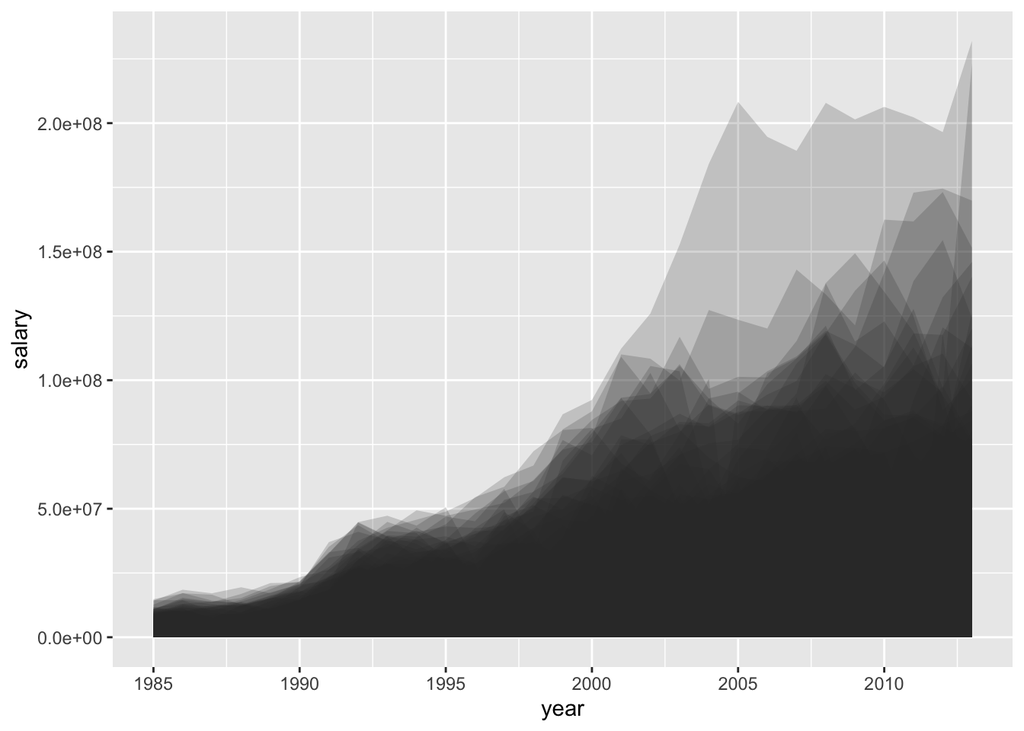

```r
ggplot(salaries_per_teams, aes(x = yearID)) + geom_area(aes(y = ATL), alpha = .2) + geom_area(aes(y = BAL), alpha = .2) +geom_area(aes(y = BOS), alpha = .2) +geom_area(aes(y = CHA), alpha = .2) +geom_area(aes(y = CHN), alpha = .2) +geom_area(aes(y = CIN), alpha = .2) +geom_area(aes(y = CLE), alpha = .2) +geom_area(aes(y = DET), alpha = .2) +geom_area(aes(y = HOU), alpha = .2) +geom_area(aes(y = KCA), alpha = .2) +geom_area(aes(y = LAN), alpha = .2) +geom_area(aes(y = MIN), alpha = .2) +geom_area(aes(y = ML4), alpha = .2) +geom_area(aes(y = MON), alpha = .2) +geom_area(aes(y = NYA), alpha = .2) +geom_area(aes(y = NYN), alpha = .2) +geom_area(aes(y = OAK), alpha = .2) +geom_area(aes(y = PHI), alpha = .2) +geom_area(aes(y = PIT), alpha = .2) +geom_area(aes(y = SDN), alpha = .2) +geom_area(aes(y = SEA), alpha = .2) +geom_area(aes(y = SFN), alpha = .2) +geom_area(aes(y = SLN), alpha = .2) +geom_area(aes(y = TEX), alpha = .2) +geom_area(aes(y = TOR), alpha = .2) +geom_area(aes(y = COL), alpha = .2) +geom_area(aes(y = FLO), alpha = .2) +geom_area(aes(y = ANA), alpha = .2) +geom_area(aes(y = ARI), alpha = .2) +geom_area(aes(y = MIL), alpha = .2) +geom_area(aes(y = TBA), alpha = .2) +geom_area(aes(y = LAA), alpha = .2) +geom_area(aes(y = WAS), alpha = .2) +geom_area(aes(y = salaries_per_teams$MIA), alpha = .2) + geom_area(aes(y = salaries_per_teams$CAL), alpha = .2) + labs(x = "year", y = "salary")
```

Each shadow of this plot represents a team. Since there are many overlaping teams there was no optimal way to desplay them all in the same plot. The salary of all teams tends to increase with time. All suffer of fluctuations in this amount but overall it increases. The exception are those teams that stop existing or making money. Then their curve dives to zero. Others could be seen being born if they start from zero at any of those years.

### 12. Explore the change in salary over time. Use a plot. Identify the teams that won the world series or league on the plot. How does salary relate to winning the league and/or world series.

To explore the change on salary overtime we can use the dataframe obtained in the question above. In addition we can use the table SeriesPost to find the list of all winners of the World series. Since this turned many results and the plot is already very populater I thought it would be better to highlight the teams that have not won the Worls series. I found those teams by checking which of the teams in the table created in question 11 were not in the list of winners.

```r
library(ggplot2)
library(RColorBrewer)
library(data.table)
```

```r
dim(salaries_per_teams)
```

```
## [1] 29 36
```

```r
teams_sal = colnames(salaries_per_teams)[-1]
salaries_per_teams_T = transpose(salaries_per_teams)
dim(salaries_per_teams_T)
```

```
## [1] 36 29
```

```r
colnames(salaries_per_teams_T) = salaries_per_teams_T[1,]
salaries_per_teams_T = salaries_per_teams_T[-1,]
salaries_per_teams_T = cbind(teams_sal, salaries_per_teams_T)
```

```r
teams_winners = dbGetQuery(con, "SELECT DISTINCT teamIDWinner FROM SeriesPost")
which_notwin = which(!(teams_sal %in% unlist(teams_winners)))
teams_sal[which_notwin]
```

```
## [1] "CAL" "WAS" "MIA"
```

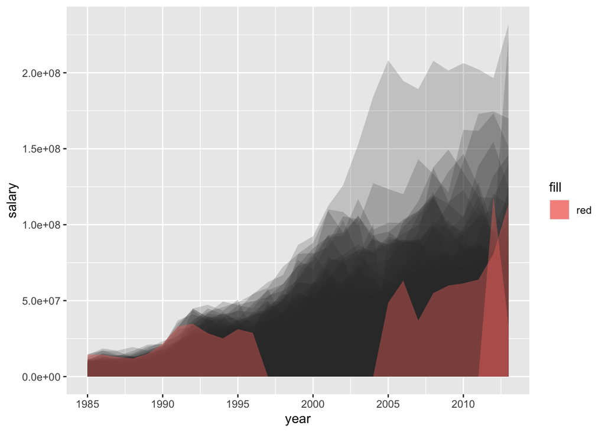

```r
ggplot(salaries_per_teams, aes(x = yearID)) + geom_area(aes(y = ATL), alpha = .2) + geom_area(aes(y = BAL), alpha = .2) +geom_area(aes(y = BOS), alpha = .2) +geom_area(aes(y = CHA), alpha = .2) +geom_area(aes(y = CHN), alpha = .2) +geom_area(aes(y = CIN), alpha = .2) +geom_area(aes(y = CLE), alpha = .2) +geom_area(aes(y = DET), alpha = .2) +geom_area(aes(y = HOU), alpha = .2) +geom_area(aes(y = KCA), alpha = .2) +geom_area(aes(y = LAN), alpha = .2) +geom_area(aes(y = MIN), alpha = .2) +geom_area(aes(y = ML4), alpha = .2) +geom_area(aes(y = MON), alpha = .2) +geom_area(aes(y = NYA), alpha = .2) +geom_area(aes(y = NYN), alpha = .2) +geom_area(aes(y = OAK), alpha = .2) +geom_area(aes(y = PHI), alpha = .2) +geom_area(aes(y = PIT), alpha = .2) +geom_area(aes(y = SDN), alpha = .2) +geom_area(aes(y = SEA), alpha = .2) +geom_area(aes(y = SFN), alpha = .2) +geom_area(aes(y = SLN), alpha = .2) +geom_area(aes(y = TEX), alpha = .2) +geom_area(aes(y = TOR), alpha = .2) +geom_area(aes(y = COL), alpha = .2) +geom_area(aes(y = FLO), alpha = .2) +geom_area(aes(y = ANA), alpha = .2) +geom_area(aes(y = ARI), alpha = .2) +geom_area(aes(y = MIL), alpha = .2) +geom_area(aes(y = TBA), alpha = .2) +geom_area(aes(y = LAA), alpha = .2) +geom_area(aes(y = WAS, fill = "red"), alpha = .4) +geom_area(aes(y = salaries_per_teams$MIA, fill = "red"), alpha = .4) + geom_area(aes(y = salaries_per_teams$CAL, fill = "red"), alpha = .4) + labs(x = "year", y = "salary")
```

The teams that have not won a World Series are CAL, WAS, and MIA and they are marked in red on the plot above. From the look of the table these teams do not earn as much as everyone else. Two of them even dived to or close to zero. One of these teams stop existing. Perhaps they were not very good. Another one is quite new adn that might be the rason they are not doing so well. It seems like the teams that do the best have more than a few years of existance.

### 13. Compare payrolls for the teams that are in the same leagues, and then in the same divisions. Are there any interesting characteristics? Have certain teams always had top payrolls over the years? Is there a connection between payroll and performance?

To answer this question we can compute the total salaries that players in those teams won across all years and then focus separatly in the league and division separation when we plot them. This will help us identify if there re meaningful differences in the big picture.

Since division information has to be obtain from another table we use table teams and merge with the table containing salary and teamID information through teamID to match the division of each team.

To address the next part of this question we can look at the teams with the top 6 salaries of each year and count the occurances of each.

Finally to measure performance we can use the variable w containing the number of wins a team has each year. If we sum the wins a team has overall we can compare it with its overall payroll to see if we can identify a relationship or trend.

```r
salary_league = dbGetQuery(con, "SELECT teamID, SUM(salary) AS salary, lgID FROM Salaries GROUP BY teamID")
head(salary_league)
```

```
##   teamID     salary lgID
## 1    ANA  468091973   AL
## 2    ARI 1112113728   NL
## 3    ATL 1785337784   NL
## 4    BAL 1526784038   AL
## 5    BOS 2293681006   AL
## 6    CAL  271978930   AL
```

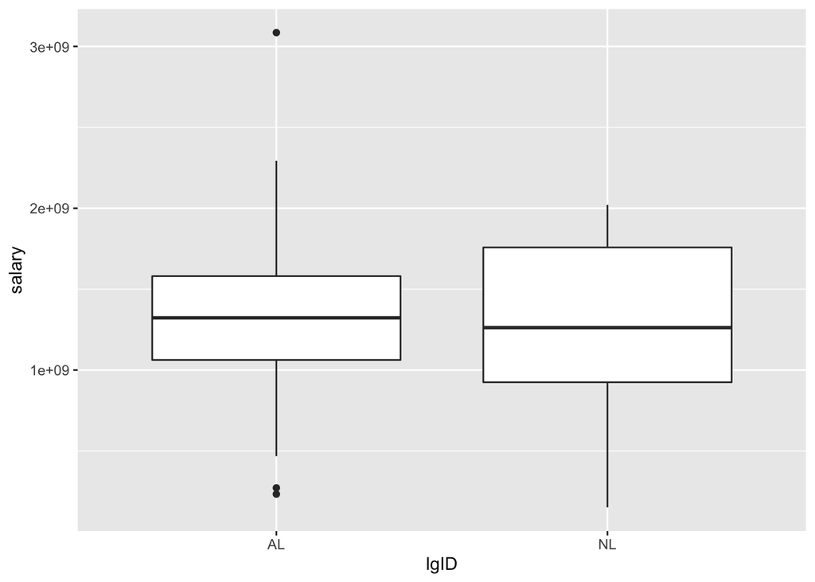

```r
ggplot(salary_league, aes(x = lgID, y = salary)) + geom_boxplot()
```

It would seem that there is not significant difference in the payroll across leagues.

```r
salary_team = dbGetQuery(con, "SELECT teamID, SUM(salary) AS salary FROM Salaries GROUP BY teamID")

div_team = dbGetQuery(con, "SELECT teamID, divID FROM Teams WHERE divID = 'W' OR divID = 'C' OR divID = 'E' GROUP BY teamID")
```

```r
salary_div = Reduce(function(x,y) merge(x=x, y=y, by = "teamID", all.x = TRUE), list(teamID, salary_team, div_team))
salary_div
```

```
##    teamID     salary divID
## 1     ANA  468091973     W
## 2     ARI 1112113728     W
## 3     ATL 1785337784     E
## 4     BAL 1526784038     E
## 5     BOS 2293681006     E
## 6     CAL  271978930     W
## 7     CHA 1618034643     C
## 8     CHN 1794310815     C
## 9     CIN 1326557848     C
## 10    CLE 1322864229     C
## 11    COL 1198507139     W
## 12    DET 1618342187     C
## 13    FLO  675016005     E
## 14    HOU 1372976857     C
```

[output cut: 21 more lines]

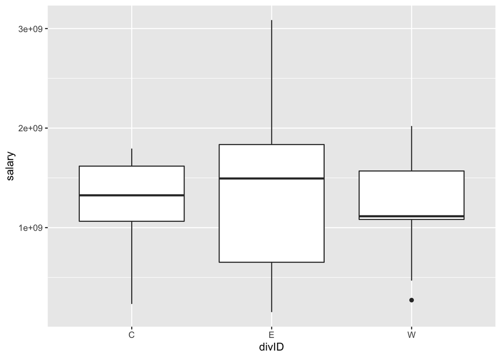

```r
ggplot(salary_div, aes(x = divID, y = salary)) + geom_boxplot()
```

It seems that division E has a higher payroll than the other two.

```r
top_1985 = head(salaries_per_teams_T[order(-salaries_per_teams_T$`1985`),c(1,2)])

top_1986 = head(salaries_per_teams_T[order(-salaries_per_teams_T$`1986`),c(1,3)])

top_1987 = head(salaries_per_teams_T[order(-salaries_per_teams_T$`1985`),c(1,4)])

top_1988 = head(salaries_per_teams_T[order(-salaries_per_teams_T$`1988`),c(1,5)])

top_1989 = head(salaries_per_teams_T[order(-salaries_per_teams_T$`1989`),c(1,6)])

top_1990 = head(salaries_per_teams_T[order(-salaries_per_teams_T$`1990`),c(1,7)])

top_1991 = head(salaries_per_teams_T[order(-salaries_per_teams_T$`1991`),c(1,8)])

top_1992 = head(salaries_per_teams_T[order(-salaries_per_teams_T$`1992`),c(1,9)])

top_1993 = head(salaries_per_teams_T[order(-salaries_per_teams_T$`1993`),c(1,10)])

top_1994 = head(salaries_per_teams_T[order(-salaries_per_teams_T$`1994`),c(1,11)])

top_1995 = head(salaries_per_teams_T[order(-salaries_per_teams_T$`1995`),c(1,12)])

top_1996 = head(salaries_per_teams_T[order(-salaries_per_teams_T$`1996`),c(1,13)])

top_1997 = head(salaries_per_teams_T[order(-salaries_per_teams_T$`1997`),c(1,14)])

top_1998 = head(salaries_per_teams_T[order(-salaries_per_teams_T$`1998`),c(1,15)])

top_1999 = head(salaries_per_teams_T[order(-salaries_per_teams_T$`1999`),c(1,16)])

top_2000 = head(salaries_per_teams_T[order(-salaries_per_teams_T$`2000`),c(1,17)])

top_2001 = head(salaries_per_teams_T[order(-salaries_per_teams_T$`2001`),c(1,18)])

top_2002 = head(salaries_per_teams_T[order(-salaries_per_teams_T$`2002`),c(1,19)])

top_2003 = head(salaries_per_teams_T[order(-salaries_per_teams_T$`2003`),c(1,20)])

top_2004 = head(salaries_per_teams_T[order(-salaries_per_teams_T$`2004`),c(1,21)])

top_2005 = head(salaries_per_teams_T[order(-salaries_per_teams_T$`2005`),c(1,22)])

top_2006 = head(salaries_per_teams_T[order(-salaries_per_teams_T$`2006`),c(1,23)])

top_2007 = head(salaries_per_teams_T[order(-salaries_per_teams_T$`2007`),c(1,24)])

top_2008 = head(salaries_per_teams_T[order(-salaries_per_teams_T$`2008`),c(1,25)])

top_2009 = head(salaries_per_teams_T[order(-salaries_per_teams_T$`2009`),c(1,26)])

top_2010 = head(salaries_per_teams_T[order(-salaries_per_teams_T$`2010`),c(1,27)])

top_2011 = head(salaries_per_teams_T[order(-salaries_per_teams_T$`2011`),c(1,28)])

top_2012 = head(salaries_per_teams_T[order(-salaries_per_teams_T$`2012`),c(1,29)])

top_2013 = head(salaries_per_teams_T[order(-salaries_per_teams_T$`2013`),c(1,30)])
```

```r
#vector with highest salary teams
top_teams = vector()
top_teams = c(as.character(top_1985[,1]),as.character(top_1986[,1]),as.character(top_1987[,1]),as.character(top_1988[,1]),as.character(top_1989[,1]),as.character(top_1990[,1]),as.character(top_1991[,1]),as.character(top_1992[,1]),as.character(top_1993[,1]),as.character(top_1994[,1]),as.character(top_1995[,1]),as.character(top_1996[,1]),as.character(top_1997[,1]),as.character(top_1998[,1]),as.character(top_1999[,1]),as.character(top_2000[,1]),as.character(top_2001[,1]),as.character(top_2002[,1]),as.character(top_2003[,1]),as.character(top_2004[,1]),as.character(top_2005[,1]),as.character(top_2006[,1]),as.character(top_2007[,1]),as.character(top_2008[,1]),as.character(top_2009[,1]),as.character(top_2010[,1]),as.character(top_2011[,1]),as.character(top_2012[,1]),as.character(top_2013[,1]))
```

```r
top = as.data.frame(table(top_teams))
top[order(-top$Freq),]
```

```
##    top_teams Freq
## 15       NYA   28
## 5        BOS   19
## 16       NYN   17
## 14       LAN   15
## 3        ATL   13
## 4        BAL    8
## 7        CHA    8
## 13       LAA    7
## 18       PHI    7
## 8        CHN    6
## 11       DET    6
## 21       TEX    6
## 6        CAL    5
## 10       CLE    5
## 22       TOR    5
## 9        CIN    4
## 12       KCA    4
## 19       SFN    3
## 20       SLN    3
## 2        ARI    2
## 17       OAK    2
## 1        ANA    1
```

```r
wins = dbGetQuery(con, "SELECT teamID, SUM(W) AS wins FROM Teams GROUP BY teamID")
head(wins)
```

```
##   teamID wins
## 1    ALT    6
## 2    ANA  664
## 3    ARI 1291
## 4    ATL 3960
## 5    BAL 4864
## 6    BFN  314
```

```r
salary_performance = Reduce(function(x,y) merge(x=x, y=y, by = "teamID", all.x = TRUE), list(teamID, salary_div[,-3], wins))
salary_performance
```

```
##    teamID     salary  wins
## 1     ANA  468091973   664
## 2     ARI 1112113728  1291
## 3     ATL 1785337784  3960
## 4     BAL 1526784038  4864
## 5     BOS 2293681006  9075
## 6     CAL  271978930  2440
## 7     CHA 1618034643  8855
## 8     CHN 1794310815 10438
## 9     CIN 1326557848  9632
## 10    CLE 1322864229  8931
## 11    COL 1198507139  1575
## 12    DET 1618342187  8921
## 13    FLO  675016005  1435
## 14    HOU 1372976857  4050
```

[output cut: 21 more lines]

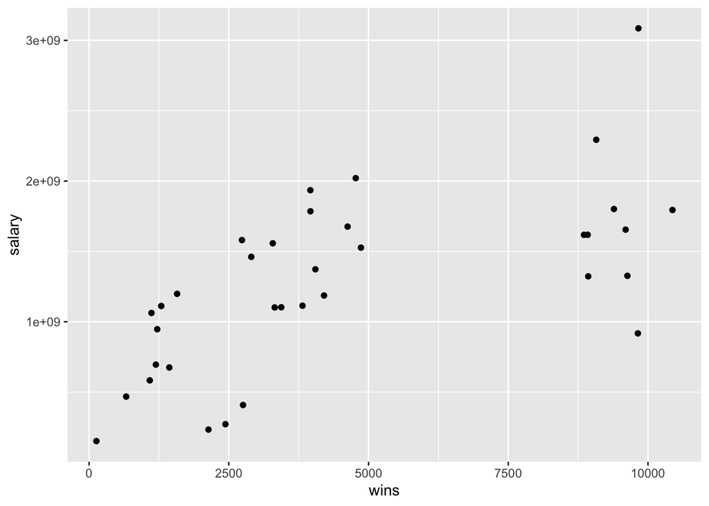

```r
ggplot(salary_performance, aes(wins, salary)) + geom_jitter()
```

There is a certain correlation between wins and salary. It could be due to a combination of factors from both sides of the interaction. It is possible that players perform beter the more you invest in them, as well as that the better they play the more money people are willing to invest on them.

14. Which player has hit the most home runs? Show the number per year.

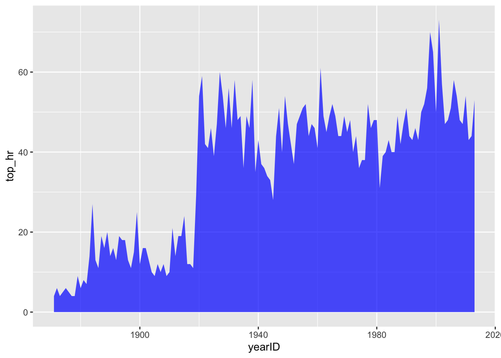

15. Has the distribution of home runs for players increased over the years?

The logic to find this answer is the same as in question 14. However in this instance it would be more helpful to look at the average of homeruns everyone accumulates per year.

```r
hr = dbGetQuery(con, "SELECT yearID, AVG(HR) AS avg_hr FROM Batting GROUP BY yearID")
head(hr)
```

```
##   yearID    avg_hr
## 1   1871 0.4086957
## 2   1872 0.2243590
## 3   1873 0.3680000
## 4   1874 0.3252033
## 5   1875 0.1834862
## 6   1876 0.3225806
```

```r
tail(hr)
```

```
##     yearID   avg_hr
## 138   2008 3.883758
## 139   2009 4.036829
## 140   2010 3.705221
## 141   2011 3.670968
## 142   2012 3.863743
## 143   2013 3.615981
```

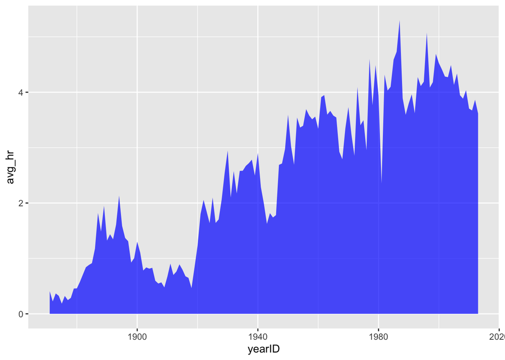

```r
ggplot(hr, aes(x = yearID, y = avg_hr)) + geom_area(fill = "blue", alpha = .7)
```

Building on the argument the plot in question 14 does, the number of average homeruns has increase significantly over the years.

### 16. Do players who hit more home runs receive higher salaries?

To answer this question we can look at the player salary in one year (lets say 2013 since its the most current) amd compare it with the number of homeruns that player hit that same year.

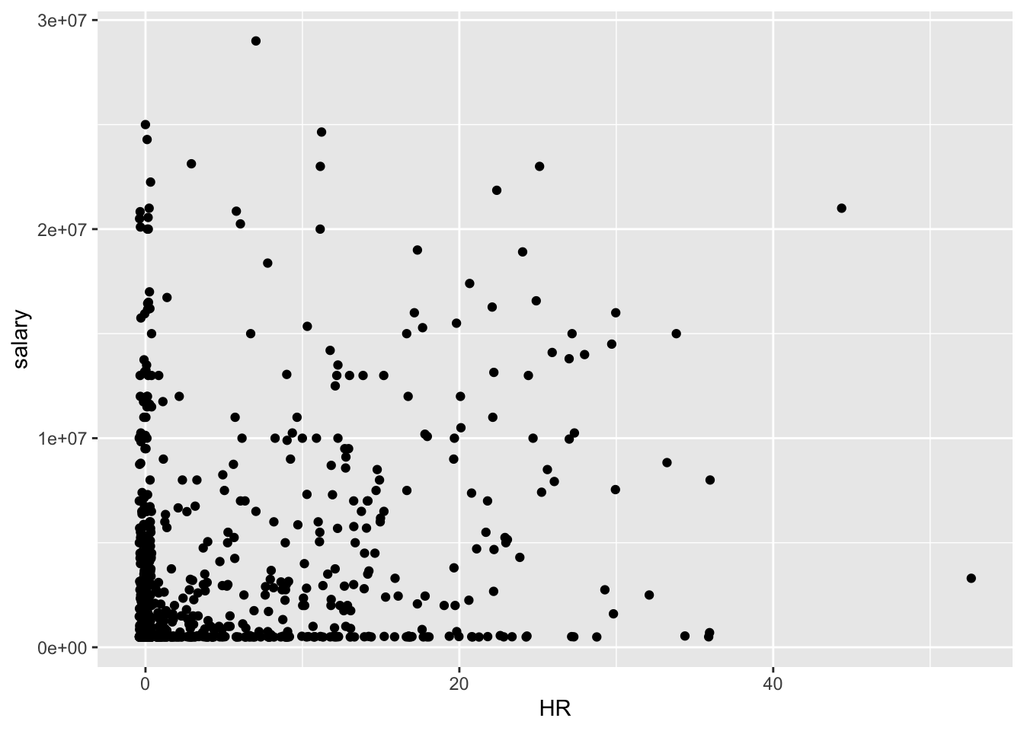

There is no visible relationship between the number of homeruns a player hits per year and their salary.